# Super Learning

David Benkeser

April 20, 2016

## Introduction

In this demonstration, we will illustrate the basic functionality of the `SuperLearner` package.

## Installing the SuperLearner package

You can execute the following commands to install the packages needed to complete this demo.

```r
# if needed, install all the necessary pacakges to execute this demo
# install.packages(c("SuperLearner","gam","caret","randomForest","arm","RCurl","MASS","tmle","ggplot2","gbm"))

# load the packages
require(SuperLearner)
require(gam)
require(caret)
require(randomForest)
require(RCurl)
require(MASS)
require(tmle)
require(ggplot2)
require(gbm)
```

## Loading data from GitHub

I have made three data sets available on GitHub that will be used in this demo. These can be read directly from GitHub using the following commands:

```r
# prediction data set
chspred <- read.csv(text = getURL("https://raw.githubusercontent.com/benkeser/sllecture/master/chspred.csv"), header = TRUE)

# statin data
statins <- read.csv(text = getURL("https://raw.githubusercontent.com/benkeser/sllecture/master/statins.csv"), header = TRUE)

# hiv vaccine data
hiv <- read.csv(text = getURL("https://raw.githubusercontent.com/benkeser/sllecture/master/hiv.csv"), header = TRUE)
```

## Super Learner with a simple library

We begin by illustrating the “default” functionality of the `SuperLearner` function. Using the `chspred` data, we are interested in predicting myocardial infarcation (`mi`) using the available covariate data. Let’s take a quick peek at the data to see what variables we have:

```r
head(chspred, 3)
```

```
##       waist    alcoh      hdl beta smoke ace      ldl      bmi aspirin
## 1 110.16419 0.000000 66.49739    0     0   1 114.2162 27.99746       0
## 2  89.97632 0.000000 50.06524    0     0   0 103.7766 20.89314       0
## 3 106.19407 8.417438 40.50595    0     0   0 165.7158 28.45541       1
##   gend      age estrgn      glu       ins   cysgfr dm   fetuina       whr
## 1    0 73.51795      0 159.9314  70.33431 75.00781  1 0.1751561 1.1689797
## 2    0 61.77225      0 153.3888  33.96945 82.74331  1 0.5716507 0.9011436
## 3    1 72.93120      0 121.7145 -17.30173 74.69888  0 0.3516775 1.1797129
##   hsed race   logcystat  logtrig    logcrp      logcre health  logkcal
## 1    1    1 -0.34202495 5.406297 2.0125961 -0.67385483      0 4.392559
## 2    0    0 -0.08465306 4.859234 3.2932809 -0.55509011      1 6.207056
## 3    0    1 -0.44510754 4.508810 0.3013225 -0.01151792      0 6.731968
##      sysbp mi
## 1 177.1345  0
## 2 136.3742  0
## 3 135.1993  0
```

For the sake of computational expediency, we will initially consider only a simple library of algorithms: a main effects GLM and an unadjusted (i.e., intercept) model. Later, we will look at how these algorithms are constructed for useage with `SuperLearner`

```r
# because cross-validation is used, we need to set to the seed to ensure reproducibility
set.seed(1234)

# execute the call to SuperLearner
sl1 <- SuperLearner(
  # Y is the outcome variable
  Y = chspred$mi,
  # X is a dataframe of predictor variables, in this case
  # everything in chspred except for mi
  X = chspred[,-ncol(chspred)],
  # newX will be discussed later, for now leave as NULL (default)
  newX = NULL,
  # family will be discussed in more detail when we see how wrappers
  # are written, for now set to binomial() for 0/1 outcome
  family = binomial(),
  # SL.library (for now) is specified as a vector of names of functions
  # that implement the desired algorithms. SL.glm and SL.mean
  # are included in the Super Learner package
  SL.library = c("SL.glm","SL.mean"),
  # method specifies how the ensembling is done, for now we will use
  # the \sum_{k=1}^K \alpha_k f_{k,n} method by using the deafult
  # option for method (method.NNLS)
  method = "method.NNLS",
  # id specifies a unique subject identifier so that whole subjects
  # are sampled in CV, not just rows of data. chspred only has one row
  # per subject, so OK to leave as NULL (default)
  id = NULL,
  # verbose controls the printing of messages of SuperLearner's progress.
  # We'll leave as FALSE (default) for now
  verbose = FALSE,
  # control contains options related to logistic ensemble (trimLogit)
  # and whether to save the fit library to look at individual
  # algorithms later. We will leave as default
  control = list(saveFitLibrary = TRUE, trimLogit = 0.001),
  # cvControl specifies parameters related to cross validation. Of note
  # the default is for V=10-fold cross validation. See ?SuperLearner
  # for more details
  cvControl = list(V = 10L, stratifyCV = FALSE, shuffle = TRUE,
                   validRows = NULL)
)

sl1
```

```
##
## Call:
## SuperLearner(Y = chspred$mi, X = chspred[, -ncol(chspred)], newX = NULL,
##     family = binomial(), SL.library = c("SL.glm", "SL.mean"), method = "method.NNLS",
##     id = NULL, verbose = FALSE, control = list(saveFitLibrary = TRUE,
##         trimLogit = 0.001), cvControl = list(V = 10L, stratifyCV = FALSE,
##         shuffle = TRUE, validRows = NULL))
##
##
##                   Risk      Coef
## SL.glm_All  0.02658219 0.8871921
## SL.mean_All 0.03041508 0.1128079
```

From the output we see that SL.glm_All had the lowest cross-validated risk and is thus the Discrete Super Learner. We will discuss why the name of each algorithm has been augmented with the suffix `_All` when we illustrate variable screening functions later in the document.

Predictions from the discrete and continuous Super Learner on the observed data can now be obtained as follows:

```r
# default call to predict
slPred <- predict(sl1)
# slPred is a list with two components
#   pred = continuous SL predictions
#   library.predict = predictions from each algorithm

# store the continuous SL predictions
cslPred <- slPred$pred

# get the discrete SL predictions
dslPred <- slPred$library.predict[,which(sl1$cvRisk==min(sl1$cvRisk))]
```

We can also obtain predictions on a new observation:

```r
# generate a new observation set to the mean of each variable
newObs <- data.frame(t(colMeans(chspred[,-ncol(chspred)])))

# all predictions on newObs
slPredNew <- predict(sl1,newdata=newObs)

# continuous SL prediction on newObs
cslPredNew <- slPredNew$pred

# discrete SL prediction on newObs
dslPredNew <- slPredNew$library.predict[,which(sl1$cvRisk==min(sl1$cvRisk))]
```

If one wishes to access the fitted object for any of the component algorithms (applied to all the data), this can be accessed through the `fitLibrary` component of the `SuperLearner` object. For example, to access the `glm` object from the `SL.glm` algorithm, we can use:

```r
# obtain gamma GLM with log-link fit
glmObject <- sl1$fitLibrary$SL.glm$object

# summarize the fit
summary(glmObject)
```

```
##
## Call:
## glm(formula = Y ~ ., family = family, data = X, weights = obsWeights)
##
## Deviance Residuals:
##     Min       1Q   Median       3Q      Max
## -1.4162  -0.2271  -0.1342  -0.0766   3.5835
##
## Coefficients:
##               Estimate Std. Error z value Pr(>|z|)
## (Intercept)  5.4405844  1.9012226   2.862  0.00421 **
## waist       -0.0064552  0.0071065  -0.908  0.36370
## alcoh        0.1127744  0.0110880  10.171  < 2e-16 ***
## hdl          0.0044309  0.0052140   0.850  0.39543
## beta         0.3328622  0.2747572   1.211  0.22571
## smoke        0.1358397  0.2704664   0.502  0.61550
## ace          0.3195770  0.2900528   1.102  0.27055
## ldl         -0.0155763  0.0019280  -8.079 6.54e-16 ***
## bmi         -0.1718827  0.0188935  -9.097  < 2e-16 ***
## aspirin      0.1921275  0.1940136   0.990  0.32204
## gend         0.1720266  0.2266058   0.759  0.44777
## age         -0.0498989  0.0165272  -3.019  0.00253 **
## estrgn      -0.2844683  0.3469420  -0.820  0.41226
## glu         -0.0016521  0.0024212  -0.682  0.49503
## ins          0.0009482  0.0022495   0.422  0.67338
## cysgfr      -0.0071902  0.0045757  -1.571  0.11609
## dm           0.4097270  0.2472677   1.657  0.09752 .
## fetuina     -0.3428327  0.7446875  -0.460  0.64525
## whr          0.0397150  0.7534039   0.053  0.95796
## hsed         0.0805406  0.1955452   0.412  0.68043
## race         0.0936239  0.2876978   0.325  0.74486
## logcystat   -0.0288129  0.3140621  -0.092  0.92690
## logtrig     -0.0586191  0.1576144  -0.372  0.70996
## logcrp      -0.0336396  0.0715266  -0.470  0.63813
## logcre      -0.2222800  0.2643888  -0.841  0.40050
## health       0.2299788  0.2707350   0.849  0.39562
## logkcal      0.0325390  0.0410616   0.792  0.42810
## sysbp        0.0047877  0.0033635   1.423  0.15461
## ---
## Signif. codes:  0 '***' 0.001 '**' 0.01 '*' 0.05 '.' 0.1 ' ' 1
##
## (Dispersion parameter for binomial family taken to be 1)
##
##     Null deviance: 1280.44  on 4589  degrees of freedom
## Residual deviance:  944.26  on 4562  degrees of freedom
## AIC: 1000.3
##
## Number of Fisher Scoring iterations: 7
```

## Writing algorithms for Super Learner

We now discuss how to supply new algorithms to the `SuperLearner` function. First, it is useful to check the algorithms that are included in the `SuperLearner` by default:

```r
listWrappers()
```

```
## All prediction algorithm wrappers in SuperLearner:
```

```
##  [1] "SL.bayesglm"         "SL.caret"            "SL.caret.rpart"
##  [4] "SL.cforest"          "SL.earth"            "SL.gam"
##  [7] "SL.gbm"              "SL.glm"              "SL.glm.interaction"
## [10] "SL.glmnet"           "SL.ipredbagg"        "SL.knn"
## [13] "SL.leekasso"         "SL.loess"            "SL.logreg"
## [16] "SL.mean"             "SL.nnet"             "SL.nnls"
## [19] "SL.polymars"         "SL.randomForest"     "SL.ridge"
## [22] "SL.rpart"            "SL.rpartPrune"       "SL.step"
## [25] "SL.step.forward"     "SL.step.interaction" "SL.stepAIC"
## [28] "SL.svm"              "SL.template"
```

```
##
## All screening algorithm wrappers in SuperLearner:
```

```
## [1] "All"
## [1] "screen.corP"           "screen.corRank"        "screen.glmnet"
## [4] "screen.randomForest"   "screen.SIS"            "screen.template"
## [7] "screen.ttest"          "write.screen.template"
```

Note that both “prediction” and “screening”" algorithms are shown. We focus first on prediction algorithms; screening algorithms are discussed in the next section. Let’s look at the guts of the `SL.glm` algorithm:

```r
SL.glm
```

```
## function (Y, X, newX, family, obsWeights, ...)
## {
##     fit.glm <- glm(Y ~ ., data = X, family = family, weights = obsWeights)
##     pred <- predict(fit.glm, newdata = newX, type = "response")
##     fit <- list(object = fit.glm)
##     class(fit) <- "SL.glm"
##     out <- list(pred = pred, fit = fit)
##     return(out)
## }
## <environment: namespace:SuperLearner>
```

Note that `SL.glm` is a function that takes as input: `Y`, `X`, `newX`, `family`, `obsWeights`, and other arguments via `...`. Note that the `family` option allows one to use a single prediction function when the outcome is both binary and continuous. In this case, `SL.glm` with `family=gaussian()` will call `glm` with `family=gaussian()` (linear regression); with `family=binomial()` it calls `glm` with `family=binomial()` (logistic regression). The output of the function is a list with components `pred`, a vector of predictions computed on the `newX` object (not `X`! source of many errors in my life…), and `fit`, which contains anything that is (1) required for predicting new values later; or (2) desired for later access via the `fitLibrary` component of the `SuperLearner` object. Because this `fit` object may be used for prediction later, it is important to specify its class so that an S3 predict method can be used on the object later. Note that such a method is already included for `SL.glm`:

```r
predict.SL.glm
```

```
## function (object, newdata, ...)
## {
##     pred <- predict(object = object$object, newdata = newdata,
##         type = "response")
##     pred
## }
## <environment: namespace:SuperLearner>
```

This input/output structure is all that is needed to define a new prediction algorithm for `SuperLearner`.

As an illustration, we could write a new algorithm specifying a new `glm` algorithm that uses the Poisson error distribution and log link (default of `family = poisson()`):

```r
require(splines)

SL.poisglm <- function(Y, X, newX, family, obsWeights, ...){
  # Poisson regression can be used regardless of whether Y is
  # continuous or binary, so we will not specify anything related to
  # family

  # fit glm with family=poisson()
  fit.glm <- glm(Y ~ .,data=X, family=poisson())

  # get predictions on newX object
  pred <- predict(fit.glm, newdata=newX, type="response")

  # save the fit object
  fit <- list(object=fit.glm)

  # because this is simply a different form of glm,
  # we can use predict.SL.glm to get predictions back,
  # i.e. no need to write a new predict function
  class(fit) <- "SL.glm"

  # out must be list with named objects pred (predictions on newX)
  # and fit (anything needed to get predictions later)
  out <- list(pred=pred, fit=fit)
  return(out)
}
```

We have now defined a new algorithm for use in the SuperLearner.

These new algorithms can now be added to the library we used previously:

```r
set.seed(1234)

sl2 <- SuperLearner(
  Y = chspred$mi,
  X = chspred[,-ncol(chspred)],
  SL.library = c("SL.glm","SL.mean","SL.poisglm")
  )

sl2
```

```
##
## Call:
## SuperLearner(Y = chspred$mi, X = chspred[, -ncol(chspred)], SL.library = c("SL.glm",
##     "SL.mean", "SL.poisglm"))
##
##
##                      Risk      Coef
## SL.glm_All     0.02819407 0.6554559
## SL.mean_All    0.03041508 0.1026581
## SL.poisglm_All 0.03585962 0.2418860
```

We can double check to make sure that `predict.SL.glm` works for our the new algorithms we defined by attempting to predict on a new observation:

```r
slPredNew2 <- predict(sl2,newdata=newObs)
slPredNew2
```

```
## $pred
##            [,1]
## [1,] 0.02667622
##
## $library.predict
##      SL.glm_All SL.mean_All SL.poisglm_All
## [1,] 0.03137255  0.03137255     0.01195707
```

## Screening algorithms for the Super Learner

We now discuss how screening algorithms can be utilized to create Super Learner libraries. As the name suggests, these are algorithms that define a screening step prior to the execution of the prediction algorithm. The `SuperLearner` function will apply this screening step in each of the V folds. The combination of screening algorithm and prediction algorithm defines a new algorithm. We can look at how screening algorithms are constructed for use with the `SuperLearner` package:

```r
write.screen.template()
```

```
## screen.template <- function(Y, X, family, obsWeights, id, ...) {
##   # load required packages
##   # require('pkg')
##   if (family$family == 'gaussian') {
##
##   }
##   if (family$family == 'binomial') {
##
##   }
##   # whichVariable is a logical vector,
##   # TRUE indicates variable will be used
##   whichVariable <- rep(TRUE, ncol(X))
##   return(whichVariable)
## }
```

Let’s write a screening algorithm that only includes demographic variables:

```r
demographics <- function(X,...){
  returnCols <- rep(FALSE, ncol(X))
  returnCols[names(X) %in% c("age","gend","race","hsed")] <- TRUE
  return(returnCols)
}
```

Now we can fit the SuperLearner using the two GLMs both with all variables and only demographic variables. The call to `SuperLearner` is nearly identical; however, we now specify `SL.library` as a list, where each component is a vector of the form `c(predictionAlgorithm,screeningAlgorithm)`. To include all the covariates, we specify the `All` screening algorithm that is included in the `SuperLearner` package.

```r
set.seed(1234)

# Fit the Super Learner
sl3 <- SuperLearner(
  Y = chspred$mi,
  X = chspred[,-ncol(chspred)],
  SL.library=list(c("SL.glm","All"),c("SL.glm","denographics"),
                  c("SL.mean","All"), # not adjusted, so doesn't matter
                  c("SL.poisglm","All"),c("SL.poisglm","denographics"))
  )

sl3
```

```
##
## Call:
## SuperLearner(Y = chspred$mi, X = chspred[, -ncol(chspred)], SL.library = list(c("SL.glm",
##     "All"), c("SL.glm", "denographics"), c("SL.mean", "All"), c("SL.poisglm",
##     "All"), c("SL.poisglm", "denographics")))
##
##
##                               Risk      Coef
## SL.glm_All              0.02819407 0.0000000
## SL.glm_denographics     0.02819407 0.6554559
## SL.mean_All             0.03041508 0.1026581
## SL.poisglm_All          0.03585962 0.2418860
## SL.poisglm_denographics 0.03585962 0.0000000
```

This flexibility in combining screening and prediction algorithms to generate new algorithms allows one to easily implement a library containing a large number of candidate algorithms. Check out `listWrappers()` to see other screening functions that are useful for more high dimensional settings.

## Using different loss/ensemble functions

So far, we have been focusing on using mean-squared error loss, by virtue of using the default `method=method.NNLS`. Because our outcome is binary, we may instead prefer the negative log-likelihood loss function instead. We can easily change our original call to `SuperLearner` to this loss function:

```r
set.seed(1234)

sl4 <- SuperLearner(
  Y = chspred$mi,
  X = chspred[,-ncol(chspred)],
  SL.library=c("SL.glm","SL.mean"),
  method = "method.NNloglik"
  )

sl4
```

```
##
## Call:
## SuperLearner(Y = chspred$mi, X = chspred[, -ncol(chspred)], SL.library = c("SL.glm",
##     "SL.mean"), method = "method.NNloglik")
##
##
##                  Risk Coef
## SL.glm_All        NaN    1
## SL.mean_All 0.1399198    0
```

We may wish instead to maximize AUC (equivalent to minimizing rank loss); for this, we can specify `method=method.AUC`:

```r
set.seed(1234)

sl5 <- SuperLearner(
  Y = chspred$mi,
  X = chspred[,-ncol(chspred)],
  SL.library=c("SL.glm","SL.mean"),
  method = "method.AUC",
  family=binomial()
  )
```

```
## cvAUC version: 1.1.0
```

```
## Notice to cvAUC users: Major speed improvements in version 1.1.0
```

```r
sl5
```

```
##
## Call:
## SuperLearner(Y = chspred$mi, X = chspred[, -ncol(chspred)], family = binomial(),
##     SL.library = c("SL.glm", "SL.mean"), method = "method.AUC")
##
##
##                  Risk      Coef
## SL.glm_All  0.1583508  643.9684
## SL.mean_All 0.5996542 -798.7203
```

Or we can even write our own method. The package contains a template for doing so. It requires a function that returns a list with three components: (1) `require` lists the packages needed to execute the functions; (2) `computeCoef` is a function that takes a specific input and returns a cross validated risk estimate and vector of weight coefficients corresponding to the $K$ algorithms in the library; (3) `computePred` a function that computes the ensemble prediction.

```r
method.template
```

```
## function ()
## {
##     out <- list(require = NULL, computeCoef = function(Z, Y,
##         libraryNames, obsWeights, control, verbose, ...) {
##         cvRisk <- numeric()
##         coef <- numeric()
##         out <- list(cvRisk = cvRisk, coef = coef)
##         return(out)
##     }, computePred = function(predY, coef, control, ...) {
##         out <- crossprod(t(predY), coef)
##         return(out)
##     })
##     invisible(out)
## }
## <environment: namespace:SuperLearner>
```

## Statin Analysis – Super Learner + Efficient Estimation

We now illustrate an analysis of the statin data that combines Super Learning-derived estimates with one-step estimation and TMLE. As you learned in class, the canonical gradient of the parameter $E_0\bigl\{E_0(Y | A=1, W) - E_0(Y | A=0, W)\bigr\}$ at $(Q,g)$ in a nonparametric model is given by
$$D^*(Q,g)(o) = \frac{2a - 1}{g^a_0(w)} (y - \bar{Q}^a_0(w)) + \bar{Q}^1_0(w) - \bar{Q}^0_0(w) - \psi_0 \ .$$
The one-step estimator is defined as
$$\psi_n^+ := \Psi(Q_n) + P_n D^*(Q_n,g_n) \ .$$
We will now use the statin data to illustrate how to construct this estimator using Super Learner-based estimates of the nuisance parameters.

Let’s first take a peek at the `statin` data to familiarize ourselves with what variables are there

```r
head(statins, 3)
```

```
##   statin educ gend      bmi      hdl smoke      age race     chol      ldl
## 1      0    0    1 24.09128 67.48161     0 75.40926    1 231.2540  94.5397
## 2      0    0    0 24.04775 59.35625     0 70.24054    1 306.1297 196.1082
## 3      0    0    1 33.48020 66.70018     1 73.49698    0 195.6578 102.1743
##   hyper copd    kcal death
## 1     0    0    0.00     1
## 2     1    0 1276.99     0
## 3     1    0    0.00     0
```

First we need to estimate both the outcome regression and the propensity regression using Super Learner. We start with the propensity:

```r
# estimate g_0^1
sl.g1 <- SuperLearner(
  # our outcome is now the statin variable
  Y = statins$statin,
  # our predictors are all variables except for death and statins
  X = statins[,-c(1,ncol(statins))],
  # outcome is binary, so let's use family = binomial()
  family = binomial(),
  # and nnloglik metho
  method=method.NNloglik,
  # simple library for computational efficiency
  SL.library = c("SL.glm","SL.mean")
)

# get predicted probability that statin = 1
g1n <- sl.g1$SL.pred

# the predicted probability that statin = 0 is 1-g1n
g0n <- 1 - g1n

# get predicted probability that statin = observed value
gan <- ifelse(statins$statin==0, g0n[statins$statin==0], g1n[statins$statin==1])
```

We can now estimate the outcome regression and return predictions setting `statin` equal to zero and one:

```r
set.seed(1234)

# estimate \bar{Q}_0
sl.Q <- SuperLearner(
  # our outcome is death
  Y = statins$death,
  # our predictors are all variables other than death
  X = statins[,-ncol(statins)],
  # outcome is binary, so let's use family = binomial()
  family = binomial(),
  # and nnloglik metho
  method=method.NNloglik,
  # simple library for computational efficiency
  SL.library = c("SL.glm","SL.mean")
)

# set up a data frame where everyone has statin=1
statins1 <- statins[,-ncol(statins)]
statins1$statin <- 1

# get \bar{Q}_n^1
Q1n <- predict(sl.Q, newdata=statins1)$pred

# set up a data frame where everyone has statin=0
statins0 <- statins[,-ncol(statins)]
statins0$statin <- 0

# get \bar{Q}_n^0
Q0n <- predict(sl.Q, newdata=statins0)$pred

# get \bar{Q}_n^a
Qan <- ifelse(statins$statin==0, Q0n[statins$statin==0], Q1n[statins$statin==1])
```

We now have all the ingredients to construct the one-step estimator:

```r
# naive plug-in estimator
psi.naive <- mean(Q1n - Q0n)
psi.naive
```

```
## [1] -0.0329666
```

```r
# bias correction (P_n applied to canonical gradient)
PnDQngn <- mean((2*statins$statin - 1)/gan * (statins$death - Qan) + (Q1n - Q0n) - psi.naive)

# one step estimator
psi.os <- psi.naive + PnDQngn
psi.os
```

```
## [1] -0.01373641
```

We can also estimate $\psi_0$ using TMLE combined with Super Learning. The `tmle` package is already integrated with `SuperLearner`, so we do not have to do as much work ourselves:

```r
set.seed(1234)

tmleFit <- tmle(
  Y = statins$death,
  A = statins$statin,
  W = statins[,-c(1,ncol(statins))],
  Q.SL.library = c("SL.glm","SL.mean"),
  g.SL.library = c("SL.glm","SL.mean")
)

tmleFit
```

```
##  Additive Effect
##    Parameter Estimate:  -0.046762
##    Estimated Variance:  0.0014712
##               p-value:  0.22278
##     95% Conf Interval: (-0.12194, 0.028416)
```

## Evaluating the Super Learner

We can use the `CV.SuperLearer` function to evaluate our over-simplified library:

```r
set.seed(1234)

# fit cross-validated super learner
cvsl1 <- CV.SuperLearner(
  Y = statins$death,
  X = statins[,-ncol(statins)],
  # V specifies the number of outer CV layers used to evalute
  # the Super Learner (which by default uses 10-fold CV)
  V = 20,
  family = binomial(),
  method="method.NNLS",
  SL.library = c("SL.glm","SL.mean")
)
```

The object itself is not all that informative:

```r
cvsl1
```

```
##
## Call:
## CV.SuperLearner(Y = statins$death, X = statins[, -ncol(statins)], V = 20,
##     family = binomial(), SL.library = c("SL.glm", "SL.mean"), method = "method.NNLS")
##
##
##
## Cross-validated predictions from the SuperLearner:  SL.predict
##
## Cross-validated predictions from the discrete super learner (cross-validation selector):  discreteSL.predict
##
## Which library algorithm was the discrete super learner:  whichDiscreteSL
##
## Cross-validated prediction for all algorithms in the library:  library.predict
```

However, there is a nice plotting function to display the results:

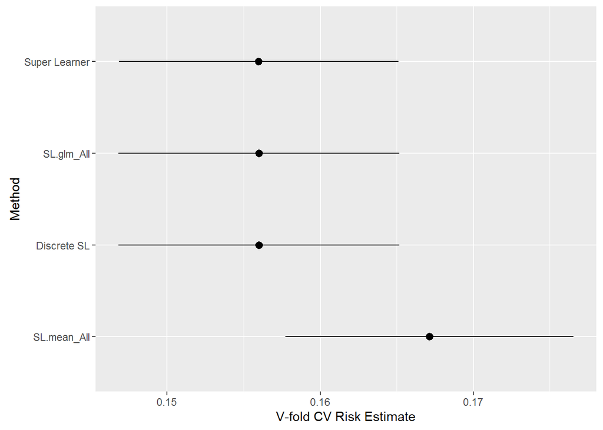

```r
# plot cross-validated risk
plot(cvsl1)
```

The plot shows the ordered cross-validated risk estimates and 95% confidence intervals about these estimates for each of the candidate algorithms, in addition to the discrete and continuous Super Learner.

## Using Super Learner to tune a single method

We can easily define a new algorithm that uses a single set of values for these parameters:

```r
SL.randomForest_m5_nt1000_ns3 <- function(...,mtry=5,ntree=1000,nodesize=3){
  SL.randomForest(...,mtry=mtry,ntree=ntree,nodesize=nodesize)
}
```

We can also use a loop to define functions over a grid of tuning parameter values:

```r
tuneGrid <-  expand.grid(mtry = c(3,5), ntree=c(500,1000), nodesize=c(1,3))

for(i in seq(nrow(tuneGrid))) {
  eval(parse(text = paste0("SL.randomForest_m",tuneGrid[i,1],"_nt",tuneGrid[i,2],"_ns",tuneGrid[i,3],
                      "<- function(..., mtry = ", tuneGrid[i, 1], ", ntree = ", tuneGrid[i, 2],
                      ", nodesize = ", tuneGrid[i,3],") { SL.randomForest(..., mtry = mtry, ntree = ntree, nodesize=nodesize)}")))
  }
```

We have now created eight new prediction algorithms with each combination of tuning parameters specified in `tuneGrid`. For example, we can look at the algorithm that uses `mtry=3`, `ntree=500`, and `nodesize=1`:

```r
SL.randomForest_m3_nt500_ns1
```

```
## function (..., mtry = 3, ntree = 500, nodesize = 1)
## {
##     SL.randomForest(..., mtry = mtry, ntree = ntree, nodesize = nodesize)
## }
```

We can collect all of these algorithms by searching through `R` objects with a similar name:

```r
# get vector of all objects in R
allObjects <- ls()
# search names of objects for 'SL.randomForest_m'
myRfObjects <- grep("SL.randomForest_m",allObjects)
# get only objects with 'SL.randomForest_m' in their name
allRf <- allObjects[myRfObjects]
allRf
```

```
## [1] "SL.randomForest_m3_nt1000_ns1" "SL.randomForest_m3_nt1000_ns3"
## [3] "SL.randomForest_m3_nt500_ns1"  "SL.randomForest_m3_nt500_ns3"
## [5] "SL.randomForest_m5_nt1000_ns1" "SL.randomForest_m5_nt1000_ns3"
## [7] "SL.randomForest_m5_nt500_ns1"  "SL.randomForest_m5_nt500_ns3"
```

```r
rf.sl <- SuperLearner(
  Y = statins$death,
  X = statins[,-ncol(statins)],
  family = binomial(),
  method="method.NNLS",
  SL.library = allRf
  )

rf.sl
```

```
##
## Call:
## SuperLearner(Y = statins$death, X = statins[, -ncol(statins)], family = binomial(),
##     SL.library = allRf, method = "method.NNLS")
##
##
##                                        Risk       Coef
## SL.randomForest_m3_nt1000_ns1_All 0.1600278 0.51486107
## SL.randomForest_m3_nt1000_ns3_All 0.1600289 0.41608786
## SL.randomForest_m3_nt500_ns1_All  0.1612663 0.00000000
## SL.randomForest_m3_nt500_ns3_All  0.1602803 0.06905107
## SL.randomForest_m5_nt1000_ns1_All 0.1615840 0.00000000
## SL.randomForest_m5_nt1000_ns3_All 0.1619054 0.00000000
## SL.randomForest_m5_nt500_ns1_All  0.1621477 0.00000000
## SL.randomForest_m5_nt500_ns3_All  0.1618559 0.00000000
```

## Combining Super Learner with the `caret` package

The `caret` package provides a uniform approach to tuning parameter selection for a number of algorithms (for a full list, see http://topepo.github.io/caret/modelList.html). This provides a way to include algorithms in the Super Learner that implicitly use cross-validation. For example, one candidate algorithm in the Super Learner might use a gradient boosted machine with fixed values for tuning parameters, while another candidate algorithm uses a gradient boosted machine with tuning parameters determined adaptively (e.g., through twenty-fold cross-validation).

The `SuperLearner` package provides an algorithm `SL.caret` to use caret to train an algorithm. I have written a slight modification to this function that fixes an issue when one trains a gradient boosted machine with `verbose=FALSE` (even with this option specified, `SL.caret` still outputs a TON of useless information).

```r
SL.caret1 <- function (Y, X, newX, family, obsWeights, method = "rf", tuneLength = 3,
                       trControl = trainControl(method = "cv", number = 20, verboseIter = FALSE),
                       metric,...)
{
  if (length(unique(Y))>2){
    if(is.matrix(Y)) Y <- as.numeric(Y)
    metric <- "RMSE"
    if(method=="gbm"){
      suppressWarnings(
        # pass verbose==FALSE directly to train (verboseIter doesn't
        # suppress output)
      fit.train <- caret::train(x = X, y = Y, weights = obsWeights,
                              metric = metric, method = method,
                              tuneLength = tuneLength,
                              trControl = trControl,verbose=FALSE)
      )
    }else{
      suppressWarnings(
      fit.train <- caret::train(x = X, y = Y, weights = obsWeights,
                                metric = metric, method = method,
                                tuneLength = tuneLength,
                                trControl = trControl)
      )
    }
    pred <- predict(fit.train, newdata = newX, type = "raw")
  }
  if (length(unique(Y))<=2) {
    metric <- "Accuracy"
    Y.f <- as.factor(Y)
    levels(Y.f) <- c("A0", "A1")
    if(method=="gbm"){
      suppressWarnings(
        # pass verbose==FALSE directly to train (verboseIter doesn't
        # suppress output)
      fit.train <- caret::train(x = X, y = Y.f, weights = obsWeights,
                              metric = metric, method = method,
                              tuneLength = tuneLength,
                              trControl = trControl, verbose = FALSE)
      )
    }else{
      suppressWarnings(
      fit.train <- caret::train(x = X, y = Y, weights = obsWeights,
                                metric = metric, method = method,
                                tuneLength = tuneLength,
                                trControl = trControl)
      )
    }
    pred <- predict(fit.train, newdata = newX, type = "prob")[,2]
  }
  fit <- list(object = fit.train)
  out <- list(pred = pred, fit = fit)
  class(out$fit) <- c("SL.caret")
  return(out)
}
```

```r
SL.gbm.caret1 <- function(...,method="gbm",tuneLength=3){
  SL.caret1(...,method=method,tuneLength=tuneLength)
}

SL.gbm.caret2 <- function(...,method="gbm",tuneLength=3, trControl=trainControl(method="cv",number=10,verboseIter=FALSE)){
  SL.caret1(...,method=method,tuneLength=tuneLength,trControl=trControl)
}
```

We can now implement the Super Learner. Note that the run time on this Super Learner will be considerably longer than previous runs due to the additional layers of cross validation.

```r
set.seed(123)

# fit super learner using three GBMs -- only use the first 150 rows
# for the sake of expediency
gbm.sl <- SuperLearner(
  Y = statins$death[1:150],
  X = statins[1:150,-ncol(statins)],
  family = binomial(),
  SL.library = c("SL.gbm","SL.gbm.caret1","SL.gbm.caret2")
)

gbm.sl
```

```
##
## Call:
## SuperLearner(Y = statins$death[1:150], X = statins[1:150, -ncol(statins)],
##     family = binomial(), SL.library = c("SL.gbm", "SL.gbm.caret1", "SL.gbm.caret2"))
##
##
##
##                        Risk Coef
## SL.gbm_All        0.1592559    1
## SL.gbm.caret1_All 0.1751551    0
## SL.gbm.caret2_All 0.1874641    0
```